# Power Analysis for Multivariate Analysis Using SEM

# Power Analysis in SEM

Author: jeremy.miles@gmail.com

Date: 2020-12-06

Status: Draft

This analysis updates the paper [A framework for power analysis using a structural equation modelling procedure](https://bmcmedresmethodol.biomedcentral.com/articles/10.1186/1471-2288-3-27) (Open access paper.)

The paper describes how to do power analysis for multivariate analysis using SEM. The examples in the paper are written using Mx. This file updates the programs and gives some examples using R and the lavaan package.

The approach relies on the fact that many analyses are special cases of SEMs, and SEMs are pretty straightforward to calculate power for, using the [Satorra-Saris method](https://link.springer.com/article/10.1007/BF02294150).

Note that I'm going to assume that you know how to use lavaan (and R) for this tutorial and won't give long explanations of models (or of power).

# Examples

The basic approach is always the same. Set up the data which matches the population that we are interested in, by making a model in lavaan that is saturated. Then get the implied means and covariance matrix (or matrices). Then fit the data to the model with the parameter of interest constrained to zero.

The chi-square from this model with the parameter constrained to zero is the non-centrality parameter.

## t test

We'll start with some simple examples, like a t-test.

### t test in SEM

There are a couple of ways to do a t-test in SEM. We can use a regression approach, or a multiple groups approach.

We'll show these by generating some data, and doing a t-test.

First we'll make up some data. We'll generate two groups, with 100 in each group; group 0 will have a population mean of 0, and group 1 will have a population mean of 0.2. Both groups will have sd = 1.

```r
set.seed(1234)
d1 <- data.frame(x = c(rep(0, 100), rep(1, 100)),
                 y = rnorm(200)) %>%
  dplyr::mutate(y = y + 0.2 * x)
```

Now we'll do a t-test.

```r
t.test(y ~ x, data = d1, var.equal = TRUE)
```

```
##
##  Two Sample t-test
##
## data:  y by x
## t = -2.7635, df = 198, p-value = 0.006258
## alternative hypothesis: true difference in means is not equal to 0
## 95 percent confidence interval:
##  -0.6820193 -0.1139905
## sample estimates:
## mean in group 0 mean in group 1
##      -0.1567617       0.2412432
```

Now we'll do it with SEM, using both the regression method and the multiple groups method.

First, we'll use the regression model:

```r
sem_reg_model <- "
  y ~ x
  x ~~ x
  y ~~ y"
sem_reg_fit <- lavaan::sem(sem_reg_model, data = d1)
summary(sem_reg_fit, ci = TRUE)
```

```
## lavaan 0.6-7 ended normally after 16 iterations
##
##   Estimator                                         ML
##   Optimization method                           NLMINB
##   Number of free parameters                          3
##
##   Number of observations                           200
##
## Model Test User Model:
##
##   Test statistic                                 0.000
##   Degrees of freedom                                 0
##
## Parameter Estimates:
##
##   Standard errors                             Standard
##   Information                                 Expected
##   Information saturated (h1) model          Structured
##
## Regressions:
##                    Estimate  Std.Err  z-value  P(>|z|) ci.lower ci.upper
##   y ~
##     x                 0.398    0.143    2.777    0.005    0.117    0.679
##
## Variances:
##                    Estimate  Std.Err  z-value  P(>|z|) ci.lower ci.upper
##     x                 0.250    0.025   10.000    0.000    0.201    0.299
##    .y                 1.027    0.103   10.000    0.000    0.826    1.228
```

Second, the multiple group approach.

```r
sem_mg_model <- "
  y ~ c(ma, mb) * 1
  y ~~ y
  d1 := ma - mb
"
sem_mg_fit <- lavaan::sem(sem_mg_model, data = d1, group = "x")
summary(sem_mg_fit, ci = TRUE)
```

```
## lavaan 0.6-7 ended normally after 9 iterations
##
##   Estimator                                         ML
##   Optimization method                           NLMINB
##   Number of free parameters                          4
##
##   Number of observations per group:
##     0                                              100
##     1                                              100
##
## Model Test User Model:
##
##   Test statistic                                 0.000
##   Degrees of freedom                                 0
##   Test statistic for each group:
##     0                                            0.000
##     1                                            0.000
##
## Parameter Estimates:
##
##   Standard errors                             Standard
##   Information                                 Expected
##   Information saturated (h1) model          Structured
##
##
## Group 1 [0]:
##
## Intercepts:
##                    Estimate  Std.Err  z-value  P(>|z|) ci.lower ci.upper
##     y         (ma)   -0.157    0.100   -1.569    0.117   -0.353    0.039
##
## Variances:
##                    Estimate  Std.Err  z-value  P(>|z|) ci.lower ci.upper
##     y                 0.999    0.141    7.071    0.000    0.722    1.276
##
##
## Group 2 [1]:
##
## Intercepts:
##                    Estimate  Std.Err  z-value  P(>|z|) ci.lower ci.upper
##     y         (mb)    0.241    0.103    2.349    0.019    0.040    0.443
##
## Variances:
##                    Estimate  Std.Err  z-value  P(>|z|) ci.lower ci.upper
##     y                 1.055    0.149    7.071    0.000    0.762    1.347
##
## Defined Parameters:
##                    Estimate  Std.Err  z-value  P(>|z|) ci.lower ci.upper
##     d1               -0.398    0.143   -2.777    0.005   -0.679   -0.117
```

Cool! Same results (to the third decimal place.)

We'll cover an extra little detail. The t-test is often said to assume homogeneity of variance - this assumption only really matters if your sample sizes are different in the two groups, however the t-test, by default, corrects for homogeneity of variance - although you can turn this off.

We'll generate some data which violates homogeneity of variance.

```r
set.seed(321)
d2 <- data.frame(x = c(rep(0, 100), rep(1, 200)),
                 y = rnorm(300)) %>%
  dplyr::mutate(y = ifelse(x == 1, y = y * 2 + 0.2, y))

t.test(y ~ x, data = d2, var.equal = FALSE)
```

```
##
##  Welch Two Sample t-test
##
## data:  y by x
## t = -2.0481, df = 297.16, p-value = 0.04143
## alternative hypothesis: true difference in means is not equal to 0
## 95 percent confidence interval:
##  -0.69254254 -0.01382235
## sample estimates:
## mean in group 0 mean in group 1
##     0.009067669     0.362250110
```

```r
t.test(y ~ x, data = d2, var.equal = TRUE)
```

```
##
##  Two Sample t-test
##
## data:  y by x
## t = -1.6499, df = 298, p-value = 0.1
## alternative hypothesis: true difference in means is not equal to 0
## 95 percent confidence interval:
##  -0.77444976  0.06808487
## sample estimates:
## mean in group 0 mean in group 1
##     0.009067669     0.362250110
```

We can relax the homogeneity of variance assumption in the multiple groups test by allowing the variances to differ across groups.

```r
sem_mg_model_hov <- "
  y ~ c(ma, mb) * 1
  y ~~  c(va, vb) * y
  d := ma - mb
  va == vb
"

sem_mg_model_no_hov <- "
  y ~ c(ma, mb) * 1
  y ~~ c(va, vb) *  y
  d := ma - mb
"

sem_mg_fit_hov <- lavaan::sem(sem_mg_model_hov, data = d2, group = "x")
summary(sem_mg_fit_hov, ci = TRUE)
```

```
## lavaan 0.6-7 ended normally after 13 iterations
##
##   Estimator                                         ML
##   Optimization method                           NLMINB
##   Number of free parameters                          4
##   Number of equality constraints                     1
##
##   Number of observations per group:
##     0                                              100
##     1                                              200
##
## Model Test User Model:
##
##   Test statistic                                60.891
##   Degrees of freedom                                 1
##   P-value (Chi-square)                           0.000
##   Test statistic for each group:
##     0                                           50.860
##     1                                           10.030
##
## Parameter Estimates:
##
##   Standard errors                             Standard
##   Information                                 Expected
##   Information saturated (h1) model          Structured
##
##
## Group 1 [0]:
##
## Intercepts:
##                    Estimate  Std.Err  z-value  P(>|z|) ci.lower ci.upper
##     y         (ma)    0.009    0.174    0.052    0.958   -0.332    0.350
##
## Variances:
##                    Estimate  Std.Err  z-value  P(>|z|) ci.lower ci.upper
##     y         (va)    3.035    0.248   12.247    0.000    2.549    3.520
##
##
## Group 2 [1]:
##
## Intercepts:
##                    Estimate  Std.Err  z-value  P(>|z|) ci.lower ci.upper
##     y         (mb)    0.362    0.123    2.941    0.003    0.121    0.604
##
## Variances:
##                    Estimate  Std.Err  z-value  P(>|z|) ci.lower ci.upper
##     y         (vb)    3.035    0.248   12.247    0.000    2.549    3.520
##
## Defined Parameters:
##                    Estimate  Std.Err  z-value  P(>|z|) ci.lower ci.upper
##     d                -0.353    0.213   -1.655    0.098   -0.771    0.065
##
## Constraints:
##                                                |Slack|
##     va - (vb)                                    0.000
```

```r
sem_mg_fit_no_hov <- lavaan::sem(sem_mg_model_no_hov, data = d2, group = "x")
summary(sem_mg_fit_no_hov, ci = TRUE)
```

```
## lavaan 0.6-7 ended normally after 13 iterations
##
##   Estimator                                         ML
##   Optimization method                           NLMINB
##   Number of free parameters                          4
##
##   Number of observations per group:
##     0                                              100
##     1                                              200
##
## Model Test User Model:
##
##   Test statistic                                 0.000
##   Degrees of freedom                                 0
##   Test statistic for each group:
##     0                                            0.000
##     1                                            0.000
##
## Parameter Estimates:
##
##   Standard errors                             Standard
##   Information                                 Expected
##   Information saturated (h1) model          Structured
##
##
## Group 1 [0]:
##
## Intercepts:
##                    Estimate  Std.Err  z-value  P(>|z|) ci.lower ci.upper
##     y         (ma)    0.009    0.095    0.095    0.924   -0.177    0.195
##
## Variances:
##                    Estimate  Std.Err  z-value  P(>|z|) ci.lower ci.upper
##     y         (va)    0.904    0.128    7.071    0.000    0.654    1.155
##
##
## Group 2 [1]:
##
## Intercepts:
##                    Estimate  Std.Err  z-value  P(>|z|) ci.lower ci.upper
##     y         (mb)    0.362    0.143    2.530    0.011    0.082    0.643
##
## Variances:
##                    Estimate  Std.Err  z-value  P(>|z|) ci.lower ci.upper
##     y         (vb)    4.100    0.410   10.000    0.000    3.296    4.903
##
## Defined Parameters:
##                    Estimate  Std.Err  z-value  P(>|z|) ci.lower ci.upper
##     d                -0.353    0.172   -2.055    0.040   -0.690   -0.016
```

We get the same results (and the same difference in statistical significance).

However, we can relax the homogeneity of variance assumption by using a robust estimator (e.g. Satorra-Bentler Chi-Square and related; also called a sandwich estimator). In SEM, we think about robust estimates as being about distributional assumptions, but they also relax the homogeneity of variance assumption.

```r
sem_reg_model <- "
  y ~ x
  y ~~ y
  "
sem_reg_hov <- lavaan::sem(sem_reg_model, data = d2)
sem_reg_no_hov <- lavaan::sem(sem_reg_model, data = d2,
                              estimator = "MLR")
summary(sem_reg_hov)
```

```
## lavaan 0.6-7 ended normally after 13 iterations
##
##   Estimator                                         ML
##   Optimization method                           NLMINB
##   Number of free parameters                          2
##
##   Number of observations                           300
##
## Model Test User Model:
##
##   Test statistic                                 0.000
##   Degrees of freedom                                 0
##
## Parameter Estimates:
##
##   Standard errors                             Standard
##   Information                                 Expected
##   Information saturated (h1) model          Structured
##
## Regressions:
##                    Estimate  Std.Err  z-value  P(>|z|)
##   y ~
##     x                 0.353    0.213    1.655    0.098
##
## Variances:
##                    Estimate  Std.Err  z-value  P(>|z|)
##    .y                 3.035    0.248   12.247    0.000
```

```r
summary(sem_reg_no_hov)
```

```
## lavaan 0.6-7 ended normally after 13 iterations
##
##   Estimator                                         ML
##   Optimization method                           NLMINB
##   Number of free parameters                          2
##
##   Number of observations                           300
##
## Model Test User Model:
##                                               Standard      Robust
##   Test Statistic                                 0.000       0.000
##   Degrees of freedom                                 0           0
##
## Parameter Estimates:
##
##   Standard errors                             Sandwich
##   Information bread                           Observed
##   Observed information based on                Hessian
##
## Regressions:
##                    Estimate  Std.Err  z-value  P(>|z|)
##   y ~
##     x                 0.353    0.172    2.055    0.040
##
## Variances:
##                    Estimate  Std.Err  z-value  P(>|z|)
##    .y                 3.035    0.286   10.602    0.000
```

Same result! Whoo hoo!

Finally, we don't need the raw data to calculate an SEM. We can do it with the summary data. For a multiple group model, all we need is the mean of the two groups, the (co)variance(s) of the two groups, and the number in each group.

Each of these needs to be in a list, with two items. The variances need to be in a matrix. We show how to create the summary data below. (If you have the data, you wouldn't do this, but if you only have the summary data we'll see later that you can just type the values in.)

```r
df_summary <- d2 %>%
  dplyr::group_by(x) %>%
  dplyr::summarise(m = mean(y),
                   n = n(),
                   var = var(y))
list_means <- list(df_summary$m[[1]], df_summary$m[[2]])
list_ns <- list(df_summary$n[[1]], df_summary$n[[2]])
list_vars <- list(matrix(df_summary$var[[1]]),
                  matrix(df_summary$var[[2]]))
# name rows and columns for each variable
list_vars <- lapply(list_vars, function(mat) {
  rownames(mat) <- colnames(mat) <- "y"
  return(mat)
})

list_means
```

```
## [[1]]
## [1] 0.009067669
##
## [[2]]
## [1] 0.3622501
```

```r
list_ns
```

```
## [[1]]
## [1] 100
##
## [[2]]
## [1] 200
```

```r
list_vars
```

```
## [[1]]
##          y
## y 0.913495
##
## [[2]]
##          y
## y 4.120183
```

Now we can fit the same models as before, but using summary data. All we change is the data, we don't change the models.

```r
sem_mg_fit_hov_summary <-
  lavaan::sem(sem_mg_model_hov,
              sample.mean = list_means,
              sample.cov = list_vars,
              sample.nobs = list_ns)
sem_mg_fit_no_hov_summary <-
  lavaan::sem(sem_mg_model_no_hov,
              sample.mean = list_means,
              sample.cov = list_vars,
              sample.nobs = list_ns)
summary(sem_mg_fit_hov_summary)
```

```
## lavaan 0.6-7 ended normally after 13 iterations
##
##   Estimator                                         ML
##   Optimization method                           NLMINB
##   Number of free parameters                          4
##   Number of equality constraints                     1
##
##   Number of observations per group:
##     Group 1                                        100
##     Group 2                                        200
##
## Model Test User Model:
##
##   Test statistic                                60.891
##   Degrees of freedom                                 1
##   P-value (Chi-square)                           0.000
##   Test statistic for each group:
##     Group 1                                     50.860
##     Group 2                                     10.030
##
## Parameter Estimates:
##
##   Standard errors                             Standard
##   Information                                 Expected
##   Information saturated (h1) model          Structured
##
##
## Group 1 [Group 1]:
##
## Intercepts:
##                    Estimate  Std.Err  z-value  P(>|z|)
##     y         (ma)    0.009    0.174    0.052    0.958
##
## Variances:
##                    Estimate  Std.Err  z-value  P(>|z|)
##     y         (va)    3.035    0.248   12.247    0.000
##
##
## Group 2 [Group 2]:
##
## Intercepts:
##                    Estimate  Std.Err  z-value  P(>|z|)
##     y         (mb)    0.362    0.123    2.941    0.003
##
## Variances:
##                    Estimate  Std.Err  z-value  P(>|z|)
##     y         (vb)    3.035    0.248   12.247    0.000
##
## Defined Parameters:
##                    Estimate  Std.Err  z-value  P(>|z|)
##     d                -0.353    0.213   -1.655    0.098
##
## Constraints:
##                                                |Slack|
##     va - (vb)                                    0.000
```

```r
summary(sem_mg_fit_no_hov_summary)
```

```
## lavaan 0.6-7 ended normally after 13 iterations
##
##   Estimator                                         ML
##   Optimization method                           NLMINB
##   Number of free parameters                          4
##
##   Number of observations per group:
##     Group 1                                        100
##     Group 2                                        200
##
## Model Test User Model:
##
##   Test statistic                                 0.000
##   Degrees of freedom                                 0
##   Test statistic for each group:
##     Group 1                                      0.000
##     Group 2                                      0.000
##
## Parameter Estimates:
##
##   Standard errors                             Standard
##   Information                                 Expected
##   Information saturated (h1) model          Structured
##
##
## Group 1 [Group 1]:
##
## Intercepts:
##                    Estimate  Std.Err  z-value  P(>|z|)
##     y         (ma)    0.009    0.095    0.095    0.924
##
## Variances:
##                    Estimate  Std.Err  z-value  P(>|z|)
##     y         (va)    0.904    0.128    7.071    0.000
##
##
## Group 2 [Group 2]:
##
## Intercepts:
##                    Estimate  Std.Err  z-value  P(>|z|)
##     y         (mb)    0.362    0.143    2.530    0.011
##
## Variances:
##                    Estimate  Std.Err  z-value  P(>|z|)
##     y         (vb)    4.100    0.410   10.000    0.000
##
## Defined Parameters:
##                    Estimate  Std.Err  z-value  P(>|z|)
##     d                -0.353    0.172   -2.055    0.040
```

## Power

OK, now we've established that we can do t-tests with SEM. Why do we care?

We care because calculating power for SEMs can be a lot easier (and quicker) than calculating power using other methods.

First we'll calculate power for a t-test using the power.t.test() function, for d = 0.2, n = 100 (per group).

```r
power.t.test(d = 0.2, n = 100)
```

```
##
##      Two-sample t test power calculation
##
##               n = 100
##           delta = 0.2
##              sd = 1
##       sig.level = 0.05
##           power = 0.2902664
##     alternative = two.sided
##
## NOTE: n is number in *each* group
```

The Satorra-Saris method makes it easy to get power from SEM. First, set up your data that contains effects of the magnitud you want to test. We'll use the multiple groups approach, and instead of calculating the means, variances, etc from the data, we'll just type them in.

Means are 0 and 0.2, variances are 1.00, and ns are 100

```r
mat <- matrix(1)
rownames(mat) <- "y"
colnames(mat) <- "y"
covs <- list(mat, mat)
means <- list(0, 0.2)
ns <- list(100, 100)
```

Now we have the population data, we can fit the null model to it. We free all of the parameters, except the single one that we are interested in. Then we fit that model.

```r
model_mg_1_null <- "
  y ~~ y
  y ~  c(a, a) * 1  "
fit_mg_1_null <- lavaan::sem(
  model_mg_1_null,
  sample.cov = covs,
  sample.mean = means,
  sample.nobs = ns)
summary(fit_mg_1_null)
```

```
## lavaan 0.6-7 ended normally after 6 iterations
##
##   Estimator                                         ML
##   Optimization method                           NLMINB
##   Number of free parameters                          4
##   Number of equality constraints                     1
##
##   Number of observations per group:
##     Group 1                                        100
##     Group 2                                        100
##
## Model Test User Model:
##
##   Test statistic                                 2.010
##   Degrees of freedom                                 1
##   P-value (Chi-square)                           0.156
##   Test statistic for each group:
##     Group 1                                      1.005
##     Group 2                                      1.005
##
## Parameter Estimates:
##
##   Standard errors                             Standard
##   Information                                 Expected
##   Information saturated (h1) model          Structured
##
##
## Group 1 [Group 1]:
##
## Intercepts:
##                    Estimate  Std.Err  z-value  P(>|z|)
##     y          (a)    0.100    0.071    1.414    0.157
##
## Variances:
##                    Estimate  Std.Err  z-value  P(>|z|)
##     y                 1.000    0.141    7.071    0.000
##
##
## Group 2 [Group 2]:
##
## Intercepts:
##                    Estimate  Std.Err  z-value  P(>|z|)
##     y          (a)    0.100    0.071    1.414    0.157
##
## Variances:
##                    Estimate  Std.Err  z-value  P(>|z|)
##     y                 1.000    0.141    7.071    0.000
```

We don't want to know that. We want to know the probability of obtaining a result of statistically significant magnitude, given that the null hypothesis is false, and the population data look like the population as we defined it.

This population value of chi-square is called the non-centrality parameter (ncp).

We want to know the probability of getting a significant result, given our ncp. So we need to know what the critical value of chi-square is. To find this we use the qchisq() function.

Then we use the pchisq() function to find the power.

```r
# Find the chi-square for the population, this is ncp.
ncp <- fitMeasures(fit_mg_1_null)[["chisq"]]
## ncp
ncp
```

```
## [1] 2.010067
```

```r
## Critical Chi-Square
crit_chi <- qchisq(p = 0.95, df = 1)
## Power
1 - pchisq(q = crit_chi, df = 1, ncp = ncp)
```

```
## [1] 0.2942073
```

Look at that. Same value of power.

This was kind of complex, but the basic idea can be extended to any model that you can represent in an SEM, and that includes anova, manova, repeated measures manova, mancova, 2 way repeated measures anova, etc. We can also, as we'll see, relax some assumptions.

A nice thing about this approach is that the non-centrality parameter is a multiple of the sample size. If you double the sample size, you double the non-centrality parameter.

This is useful, because this approach tells us the power for a certain sample size. Usually, I want to know the sample size that's required for a certain power.

But how do I know how large I need my non-centrality parameter (ncp) to be? Well, a useful rule of thumb is that power of 0.8 is obtained when the non-centrality parameter is approximately equal to the chi-square that gives a p-value of around 0.005.

So, first we find out what the ncp needs to be, then we find find how many times larger (or smaller) this value is than our NCP, then we increase our sample size by this value.

```r
# Find the desired ncp
desired_ncp <- qchisq(p = 0.995, df = 1)
## sample size multiplier
n_multiplier <- desired_ncp / ncp
n_multiplier
```

```
## [1] 3.919988
```

```r
# we had ns already set up, so we can multiply this.
# But it needs to be an integer, so we round it.
new_ns <- lapply(ns, function(n) round(n_multiplier * n))
# See what the new sample sizes are
new_ns
```

```
## [[1]]
## [1] 392
##
## [[2]]
## [1] 392
```

```r
model_mg_new_null <- "
  y ~~ y
  y ~  c(a, a) * 1  "
fit_mg_new_null <- lavaan::sem(
  model_mg_new_null,
  sample.cov = covs,
  sample.mean = means,
  sample.nobs = new_ns)

ncp <- fitMeasures(fit_mg_new_null)[["chisq"]]
## ncp
ncp
```

```
## [1] 7.820912
```

```r
## Critical Chi-Square
crit_chi <- qchisq(p = 0.95, df = 1)
## Power
1 - pchisq(q = crit_chi, df = 1, ncp = ncp)
```

```
## [1] 0.7985994
```

Finally, we'll see if that's correct.

```r
power.t.test(power = 0.8, d = 0.2)
```

```
##
##      Two-sample t test power calculation
##
##               n = 393.4067
##           delta = 0.2
##              sd = 1
##       sig.level = 0.05
##           power = 0.8
##     alternative = two.sided
##
## NOTE: n is number in *each* group
```

It appears that we are out by 1. Which is certainly close enough for power analysis.

### That was a lot of effort

It was. But we can do lots of clever things now. What happens if we think we might have different variances or different sample sizes in each group? We can't use the base power functions (for different sample sizes, the pwr package has some useful functions.) We can run simulations, but these get to be hard work when we want to run lots of different tests to explore our options.

```r
n0 = 100
n1 = 400
v0 = 1
v1 = 4
diff = 0.2

set.seed(1234)
system.time({
  res <- lapply(seq(1e4), function(i) {
    d2 <- data.frame(x = c(rep(0, n0), rep(1, n1)),
                     y = rnorm(n0 + n1) * v0) %>%
      dplyr::mutate(
        y = ifelse(x == 1, (v1 * y) + 0.2, y))
    sig <- t.test(y ~ x, data = d2)$p.value < 0.05
    return(sig)
  }) %>%
    unlist() %>%
    mean()
})
```

```
##    user  system elapsed
##   44.55    0.08   44.81
```

```r
## power
res
```

```
## [1] 0.1462
```

```r
mat0 <- matrix(v0^2)
mat1 <- matrix(v1^2)
colnames(mat0) <- colnames(mat0) <- "y"
rownames(mat0) <- rownames(mat1) <- "y"
covs <- list(mat0, mat1)
means <- list(0, diff)
ns <- list(n0, n1)

model_mg_2 <- "
  y ~~ y
  y ~  c(a, a) * 1 "
fit_mg_2 <- lavaan::sem(
  model_mg_2,
  sample.cov = covs,
  sample.mean = means,
  sample.nobs = ns)

ncp <- fitMeasures(fit_mg_2)[["chisq"]]
## Critical Chi-Square
crit_chi <- qchisq(p = 0.95, df = 1)
## Power
1 - pchisq(q = crit_chi, df = 1, ncp = ncp)
```

```
## [1] 0.1457875
```

OK, let's see what sample size we need, and then test it to see if it's correct.

```r
# Find the desired ncp
desired_ncp <- qchisq(p = 0.995, df = 1)
## sample size multiplier
n_multiplier <- desired_ncp / ncp
n_multiplier
```

```
## [1] 9.817778
```

```r
ns <- lapply(ns, function(n) return(n * n_multiplier))

# new ns
ns
```

```
## [[1]]
## [1] 981.7778
##
## [[2]]
## [1] 3927.111
```

```r
model_mg_2 <- "
  y ~~ y
  y ~  c(a, a) * 1 "

fit_mg_2 <- lavaan::sem(
  model_mg_2,
  sample.cov = covs,
  sample.mean = means,
  sample.nobs = ns)

ncp <- fitMeasures(fit_mg_2)[["chisq"]]
## Critical Chi-Square
crit_chi <- qchisq(p = 0.95, df = 1)
## Power
1 - pchisq(q = crit_chi, df = 1, ncp = ncp)
```

```
## [1] 0.800043
```

If you've got a simple power problem, it's quickest to use the base R functions. If you've got a slightly more complex problem, it's quickest to run a simulation.

If you want to test 20 different sample sizes, with 20 different ratios of variances, that's going to take almost 5 hours of computer time to run the simulations - it's going to be quicker to wrap the above code into a loop, and run that.

## Repeated Measures t-test.

For the repeated measures t-test, the procedure is similar to the independent groups t-test, but instead we have one group, and we also need to specify the covariance between the two measures. If your variables are standardized (and they usually are for power analysis) then the covariance is the correlation, and things are much easier. ()

We set up a covariance matrix, and a vector of means.

```r
diff <- 0.2
corr <- 0.4
cmat <- matrix(c(1, corr,
                 corr, 1), nrow = 2)
n <- 200
colnames(cmat) <- rownames(cmat) <- c("y0", "y1")
means <- c(0, diff)

rm_t_model <- "
y0 ~~ y0
y1 ~~ y1
y0 ~~ y1
y0 ~ m0 * 1
y1 ~ m1 * 1

d := m0 - m1
d == 0
  "
rm_t_fit <- lavaan::sem(
  rm_t_model, sample.mean = means,
  sample.cov = cmat,
  sample.nobs = n)

ncp <- fitMeasures(rm_t_fit)[["chisq"]]

crit_chi <- qchisq(p = 0.95, df = 1)
## Power
1 - pchisq(q = crit_chi, df = 1, ncp = ncp)
```

```
## [1] 0.7281472
```

We can see that having a positive correlation has a dramatic effect on power.

To explore the effect of the differing correlation on power, we can wrap that code into a function, and then call it for correlations from -0.5 to 0.9.

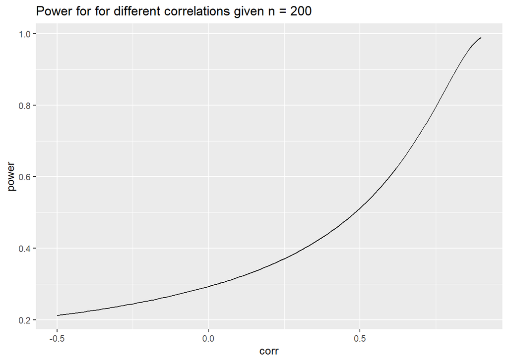

```r
RMPower <- function(n = 100, corr = 0.4, diff = 0.2) {

  cmat <- matrix(c(1, corr,
                   corr, 1), nrow = 2)
  colnames(cmat) <- rownames(cmat) <- c("y0", "y1")
  means <- c(0, diff)

  rm_t_model <- "
  y0 ~~ y0
  y1 ~~ y1
  y0 ~~ y1
  y0 ~ m0 * 1
  y1 ~ m1 * 1

  d := m0 - m1
  d == 0
  "
  rm_t_fit <- lavaan::sem(
    rm_t_model, sample.mean = means,
    sample.cov = cmat,
    sample.nobs = n)

  ncp <- fitMeasures(rm_t_fit)[["chisq"]]

  crit_chi <- qchisq(p = 0.95, df = 1)
  ## Power
  power <- 1 - pchisq(q = crit_chi, df = 1, ncp = ncp)
  desired_ncp <- qchisq(p = 0.995, df = 1)
  ## sample size multiplier
  n_multiplier <- desired_ncp / ncp
  return(c(power = power, n80 = n_multiplier * n))
}

df_power <- lapply(seq(-.5, 0.9, 0.01), function(corr) {
  power <- RMPower(corr = corr)
  return(c(power, corr = corr))
}) %>% dplyr::bind_rows()

ggplot2::ggplot(df_power, aes(x = corr, y = power)) +
  geom_line() +
  ggtitle(paste0("Power for for different correlations given n = ", n))
```

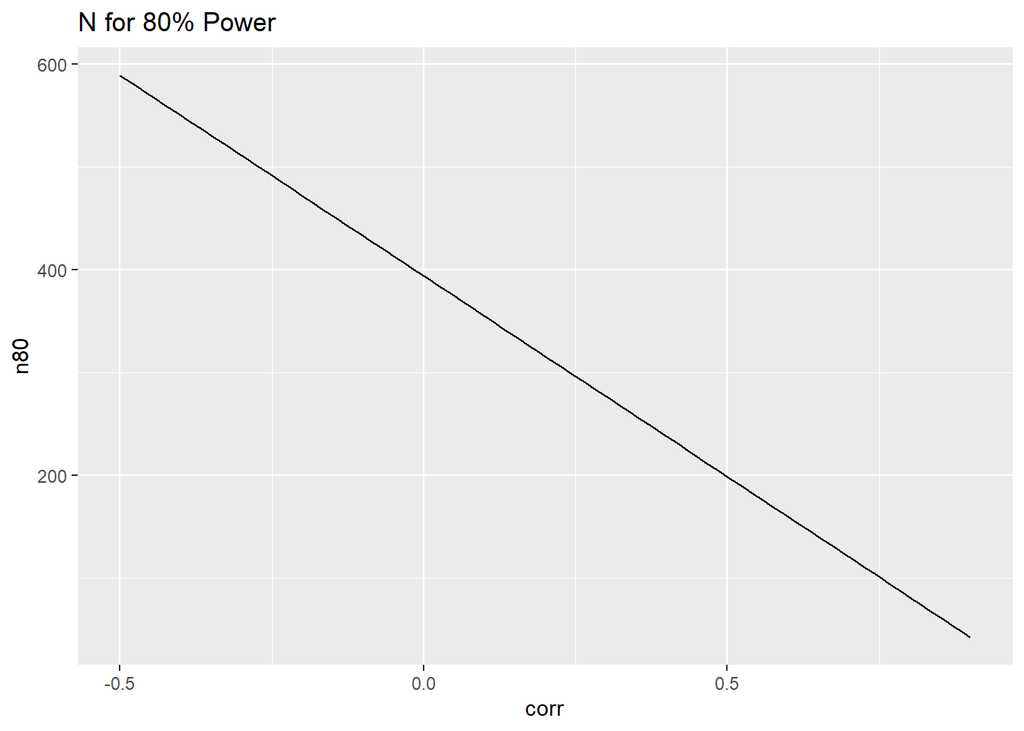

```r
ggplot2::ggplot(df_power, aes(x = corr, y = n80)) +
  geom_line() +
  ggtitle("N for 80% Power")
```

With the independent groups t-test, the power for a sample size of 200 was 0.29. The repeated measures t-test, with a correlation of zero, gives (approximately) the same power for a sample size of 100 (which is equivalent to 200 observations, so the same amount of information). As the correlation increaes, the power increases. In the rare event that your measures are negatively correlated, power is lower than the independent samples t-test.

The second chart shows how the required sample size for 80% power changes as a function of the correlation between the measures. The relationship is linear. If the correlation is 0.00, n of around 400 is required for 80% power. If the correlation is 0.5, n = 200 is required (and if the correlation is 1.00, the power is infinite because the standard error of the differences is zero.)